# 淘宝用户行为数据分析项目目录

# 项目介绍

- 领域：电商
- 数据来源：天池公开数据集
- 数据情况：用户行为数据
- 时间跨度：2017年11月25日 至 2017年12月3日(9天)
- 分析工具：
  - 代码语言：Python
  - 数据库：Mysql
  - 可视化工具：Pyecharts、Matplotlib、Seaborn

本数据集由阿里巴巴提供的一亿多条的淘宝用户行为数据，包含了2017年11月25日至2017年12月3日之间，约一百万随机用户的所有行为（行为包括点击、购买、加购、收藏），数据集的每一行表示一条用户行为，针对的对象是商品详情页。

# 分析目的

对淘宝用户行为数据进行分析，并给出改善建议。

# 分析结论

## 每日基本情况

[figure not shown]

## 每日PV、UV趋势以及其增长率情况

[figure not shown]

日pv、日uv 整体呈现上升趋势，在12月2日达到最高峰、3日有所回落，PV日环比、UV日环比在12月2日增长接近25%

上述指标都在12月2日~ 3日有了大幅度提升，12月2日~ 3日虽然是周末，但是结合上个周末11月25日~ 26日的流量分析，可以排除周末原因；由于12月2日~3日距离双12较近，推测较大可能的原因是双12系列促销活动预热所带来的流量增加。

## 漏斗分析

用户使用淘宝的常见过程是：浏览（PV），之后可以收藏（fav）、加入购物车（cart），再到购买（buy）。其中，fav、cart不是购买的必须过程。

收藏功能主要是帮助用户收藏自己喜欢但不立即购买的商品，而购物车既有类似收藏商品的功能，但主要还是方便用户批量购买商品，两者都是用于提升用户购物体验。但是商品收藏之后要购买还是面临着加入购物车和直接购买的选择，因此，本文的漏斗分析会将收藏排除在外，由于数据集的行为类型有限，没有下单、支付环节，这里只分析浏览、加购物车、购买的转化。

- 转化节点：**浏览、加购物车、购买**
- 时间窗口：9天
- 转化基线：**每一步作为下一步的基线**
- 转化路径：
  - 转化路径一：浏览-加购物车-购买
  - 转化路径二：浏览-购买

### 浏览-加购物车-购买三大环节的转化漏斗

[figure not shown]

在9天内，有53.09%的用户在浏览后加入了购物车； 其中有59.22%的用户会在加入购物车进行购买行为； 由于数据集时间范围的限制，暂时无法知道这各环节的转化率是否正常，需要与历史数据对比才能作出最终的判断。

### 浏览-购买两大环节的转化漏斗

[figure not shown]

在9天内，有32.5%的用户浏览完便会进行购买； 由于数据集时间范围的限制，暂时无法知道这各环节的转化率是否正常，需要与历史数据对比才能作出最终的判断。

## 用户行为路径分布

[figure not shown]

## 加入购物车、收藏、购买三大功能使用情况

[figure not shown]

这9天中，购买的用户占比为63.94%，使用购物车功能用户占比53.09%，使用收藏功能的用户占比26.44%。

## 收藏/加购物车-购买时间间隔分布

用户收藏/加购物车到购买的时间间隔分布，运营人员可以根据时间间隔分布，给用户设置提醒功能。

[figure not shown]

- 在这9天内，加入购物车且有购买意愿的用户中，接近60%的用户会在24h内完成购买，超过88.09%会在3天内购买；
- 收藏且有购物意愿的用户中，接近77.13%的用户会在24h内完成购买，超过92.24%的用户会在3天内购买。
- 当用户收藏和加购物车3天后还未购买，可以大致推测用户的购买意愿并不强烈，此时可以通过适当的提示\优惠活动来引导用户购买，或者推荐对应的相似商品供用户选择。

# 分析主体

**由于原数据集有1亿多条记录，数据量过大，本文只对其中200万条数据进行分析。**

## 数据集概要

- 数据集来源：[天池公开数据集](https://tianchi.aliyun.com/dataset/dataDetail?dataId=649)
- 数据集大小：1亿多条的真实用户行为数据(脱敏)【仅200万条数据进行分析】
- 数据集时间跨度：2017年11月25日 至 2017年12月3日(9天)
- 该数据集包含5字段

| 字段 | 说明 |
| --- | --- |
| User ID | 用户ID(整数型) |
| Item ID | 商品ID(整数型) |
| Category ID | 商品类目ID(整数型) |
| Behavior type | 行为类型(字符串型) |
| Timestamp | 行为发生的时间戳(整数型) |

- 行为类型的字段，包括四种情况

| 行为类型 | 说明 |
| --- | --- |
| pv | 商品详情页 pv，等价于点击 |
| buy | 商品购买 |
| cart | 将商品加入购物车 |
| fav | 收藏商品 |

**【注意：这里的行为都是针对商品详情页】**

## 导入相关库

```python
# 导入相关库
import numpy as np  # 科学计算工具包
import pandas as pd  # 数据分析工具包
import matplotlib.pyplot as plt # 图表绘制工具包
import seaborn as sns # 基于 matplot, 导入 seaborn 会修改默认的 matplotlib 配色方案和绘图样式，这会提高图表的可读性和美观性
import os,pymysql
from sqlalchemy import create_engine # 数据库

plt.rcParams['font.sans-serif'] = ['SimHei']  # 中文字体设置-黑体
plt.rcParams['axes.unicode_minus'] = False  # 解决保存图像是负号'-'显示为方块的问题
sns.set(font='SimHei')  # 解决Seaborn中文显示问题

# 在 jupyter notebook 里面显示图表
%matplotlib inline
```

## 获取数据集

知识点

read_csv()

- 参数 names : array-like, default None 用于结果的列名列表，如果数据文件中没有列标题行，就需要执行header=None。默认列表中不能出现重复，除非设定参数mangle_dupe_cols=True。

```python
# 获取数据集

columns = ["user_id","item_id","category_id","behavior_type","timestamp"]

reader = pd.read_csv("/Users/xusanshan/Downloads/UserBehavior.csv", iterator=True,names=columns)
user_behavior = reader.get_chunk(2000000)
```

## 理解数据集

通过预览数据，了解所有字段和其含义。

```python
user_behavior.head()
```

|  | user_id | item_id | category_id | behavior_type | timestamp |
| --- | --- | --- | --- | --- | --- |
| 0 | 1 | 2268318 | 2520377 | pv | 1511544070 |
| 1 | 1 | 2333346 | 2520771 | pv | 1511561733 |
| 2 | 1 | 2576651 | 149192 | pv | 1511572885 |
| 3 | 1 | 3830808 | 4181361 | pv | 1511593493 |
| 4 | 1 | 4365585 | 2520377 | pv | 1511596146 |

## 清洗数据集

### 查看数据整体信息

```python
user_behavior.info()
```

```
<class 'pandas.core.frame.DataFrame'>
RangeIndex: 2000000 entries, 0 to 1999999
Data columns (total 5 columns):
 #   Column         Dtype
---  ------         -----
 0   user_id        int64
 1   item_id        int64
 2   category_id    int64
 3   behavior_type  object
 4   timestamp      int64
dtypes: int64(4), object(1)
memory usage: 76.3+ MB
```

### 缺失值处理

```python
# 统计缺失值数量和占比

def missing_info(data,num=5):
    # func:统计缺失值数量和占比函数
    # data: dataframe类型
    # num: 数字类型，显示前几行数据
    # return: 缺失值统计\占比

    null_data = data.isnull().sum().sort_values(ascending=False)
    percent_1 = data.isnull().sum()/data.isnull().count()
    missing_data = pd.concat([null_data,percent_1.apply(lambda x: format(x, '.2%'))],axis=1,keys=['total missing','missing percentage'])
    print(missing_data.head(num))

missing_info(user_behavior)
```

```
               total missing missing percentage
timestamp                  0              0.00%
behavior_type              0              0.00%
category_id                0              0.00%
item_id                    0              0.00%
user_id                    0              0.00%
```

**缺失情况：**

- 所有字段均无缺失值，数据很干净

### 重复值处理

```python
# 查看每一行数据是否存在重复值

user_behavior.duplicated().sum()
```

```
0
```

**重复情况：**

- 没有重复值，不需要进行处理。

### 数据类型转化

```python
# 时间戳 timestamp 转 datetime 格式的函数

def timestamp_datetime(data,column_list):
    # func: 时间戳 timestamp 转 datetime 格式的函数
    # data: dataframe类型
    # num: 数字类型，显示前几行数据
    # return: 日期时间类型数据

    for i in column_list:
        data[i] = pd.to_datetime(data[i], unit='s')
    print('时间戳转换 datetime 格式完成')

data = user_behavior
column_list =['timestamp']
timestamp_datetime(data,column_list)
```

```
时间戳转换 datetime 格式完成
```

```python
user_behavior.head()
```

|  | user_id | item_id | category_id | behavior_type | timestamp |
| --- | --- | --- | --- | --- | --- |
| 0 | 1 | 2268318 | 2520377 | pv | 2017-11-24 17:21:10 |
| 1 | 1 | 2333346 | 2520771 | pv | 2017-11-24 22:15:33 |
| 2 | 1 | 2576651 | 149192 | pv | 2017-11-25 01:21:25 |
| 3 | 1 | 3830808 | 4181361 | pv | 2017-11-25 07:04:53 |
| 4 | 1 | 4365585 | 2520377 | pv | 2017-11-25 07:49:06 |

### 新增日期时间信息字段

- date
- year_month
- hour

```python
user_behavior['date'] = user_behavior['timestamp'].dt.date
user_behavior['year_month'] = user_behavior['timestamp'].dt.to_period('M')
user_behavior['hour']= user_behavior['timestamp'].dt.hour

user_behavior.head()
```

|  | user_id | item_id | category_id | behavior_type | timestamp | date | year_month | hour |
| --- | --- | --- | --- | --- | --- | --- | --- | --- |
| 0 | 1 | 2268318 | 2520377 | pv | 2017-11-24 17:21:10 | 2017-11-24 | 2017-11 | 17 |
| 1 | 1 | 2333346 | 2520771 | pv | 2017-11-24 22:15:33 | 2017-11-24 | 2017-11 | 22 |
| 2 | 1 | 2576651 | 149192 | pv | 2017-11-25 01:21:25 | 2017-11-25 | 2017-11 | 1 |
| 3 | 1 | 3830808 | 4181361 | pv | 2017-11-25 07:04:53 | 2017-11-25 | 2017-11 | 7 |
| 4 | 1 | 4365585 | 2520377 | pv | 2017-11-25 07:49:06 | 2017-11-25 | 2017-11 | 7 |

### 异常值处理

```python
# 观察数据异常情况

user_behavior.describe(include="all")
```

|  | user_id | item_id | category_id | behavior_type | timestamp | date | year_month | hour |
| --- | --- | --- | --- | --- | --- | --- | --- | --- |
| count | 2.000000e+06 | 2.000000e+06 | 2.000000e+06 | 2000000 | 2000000 | 2000000 | 2000000 | 2.000000e+06 |
| unique | NaN | NaN | NaN | 4 | 627028 | 32 | 7 | NaN |
| top | NaN | NaN | NaN | pv | 2017-11-28 08:02:20 | 2017-12-02 | 2017-11 | NaN |
| freq | NaN | NaN | NaN | 1791216 | 46 | 278200 | 1253884 | NaN |
| first | NaN | NaN | NaN | NaN | 1970-01-01 12:13:36 | NaN | NaN | NaN |
| last | NaN | NaN | NaN | NaN | 2018-08-28 10:27:12 | NaN | NaN | NaN |
| mean | 2.837831e+05 | 2.577227e+06 | 2.712752e+06 | NaN | NaN | NaN | NaN | 9.631077e+00 |
| std | 3.421325e+05 | 1.487724e+06 | 1.466843e+06 | NaN | NaN | NaN | NaN | 5.568526e+00 |
| min | 1.000000e+00 | 2.600000e+01 | 2.171000e+03 | NaN | NaN | NaN | NaN | 0.000000e+00 |
| 25% | 1.165960e+05 | 1.294040e+06 | 1.349561e+06 | NaN | NaN | NaN | NaN | 5.000000e+00 |
| 50% | 1.418930e+05 | 2.574775e+06 | 2.723483e+06 | NaN | NaN | NaN | NaN | 1.000000e+01 |
| 75% | 1.672790e+05 | 3.859124e+06 | 4.145813e+06 | NaN | NaN | NaN | NaN | 1.400000e+01 |
| max | 1.018011e+06 | 5.163067e+06 | 5.161669e+06 | NaN | NaN | NaN | NaN | 2.300000e+01 |

**异常处理**

因此需要筛选出在2017年11月25日~2017年12月3日范围的用户行为记录。

```python
# 查看异常值的详细数据

user_behavior[(pd.to_datetime('2017-11-25')>user_behavior['date'])|(user_behavior['date']>pd.to_datetime('2017-12-03'))]
```

|  | user_id | item_id | category_id | behavior_type | timestamp | date | year_month | hour |
| --- | --- | --- | --- | --- | --- | --- | --- | --- |
| 0 | 1 | 2268318 | 2520377 | pv | 2017-11-24 17:21:10 | 2017-11-24 | 2017-11 | 17 |
| 1 | 1 | 2333346 | 2520771 | pv | 2017-11-24 22:15:33 | 2017-11-24 | 2017-11 | 22 |
| 55 | 100 | 4572582 | 2188684 | pv | 2017-11-24 19:08:36 | 2017-11-24 | 2017-11 | 19 |
| 56 | 100 | 2971043 | 4869428 | pv | 2017-11-24 19:10:00 | 2017-11-24 | 2017-11 | 19 |
| 57 | 100 | 2379198 | 4869428 | pv | 2017-11-24 19:13:26 | 2017-11-24 | 2017-11 | 19 |
| ... | ... | ... | ... | ... | ... | ... | ... | ... |
| 1999208 | 174024 | 3902269 | 149192 | pv | 2017-11-24 22:43:37 | 2017-11-24 | 2017-11 | 22 |
| 1999209 | 174024 | 2903900 | 149192 | pv | 2017-11-24 22:45:13 | 2017-11-24 | 2017-11 | 22 |
| 1999210 | 174024 | 2912625 | 982926 | pv | 2017-11-24 22:46:28 | 2017-11-24 | 2017-11 | 22 |
| 1999211 | 174024 | 516669 | 982926 | pv | 2017-11-24 22:46:48 | 2017-11-24 | 2017-11 | 22 |
| 1999473 | 174038 | 1413295 | 4238377 | pv | 2017-11-24 22:54:27 | 2017-11-24 | 2017-11 | 22 |

24651 rows × 8 columns

```python
#第一种方法: 筛选出在范围内的记录

user_behavior = user_behavior[(user_behavior['date']>pd.to_datetime('2017-11-24'))&(user_behavior['date']<pd.to_datetime('2017-12-04'))]
user_behavior.info()
```

```
<class 'pandas.core.frame.DataFrame'>
Int64Index: 1975349 entries, 2 to 1999999
Data columns (total 8 columns):
 #   Column         Dtype
---  ------         -----
 0   user_id        int64
 1   item_id        int64
 2   category_id    int64
 3   behavior_type  object
 4   timestamp      datetime64[ns]
 5   date           object
 6   year_month     period[M]
 7   hour           int64
dtypes: datetime64[ns](1), int64(4), object(2), period[M](1)
memory usage: 135.6+ MB
```

```python
#第二种方法: 删除掉不在范围的记录

user_behavior=user_behavior.drop(index=user_behavior[(pd.to_datetime('2017-11-25')>user_behavior['date'])|(user_behavior['date']>pd.to_datetime('2017-12-03'))].index)
user_behavior.info()
```

```
<class 'pandas.core.frame.DataFrame'>
Int64Index: 1975349 entries, 2 to 1999999
Data columns (total 8 columns):
 #   Column         Dtype
---  ------         -----
 0   user_id        int64
 1   item_id        int64
 2   category_id    int64
 3   behavior_type  object
 4   timestamp      datetime64[ns]
 5   date           object
 6   year_month     period[M]
 7   hour           int64
dtypes: datetime64[ns](1), int64(4), object(2), period[M](1)
memory usage: 135.6+ MB
```

数据清洗后

- 样本大小：1975349 条数据
- 字段：8个
- 无缺失值，无重复值
- 有少量异常值,已处理

## 导出到数据库

```python
# 导出到 mysql 数据库的函数

def export_mysql(data,user,password,host_port,db,table_name):
    # func: 导出到 mysql 数据库函数
    # data: Dataframe 类型
    # user: 用户名
    # password: 密码
    # host_port: 主机，端口
    # db: 数据库名
    # table_name: 表名

    print('将清洗后的数据导出到 mysql')
    engine = create_engine("mysql+pymysql://{}:{}@{}/{}".format(user, password, host_port, db))
    con = engine.connect()#创建连接
    data.to_sql(table_name,engine,if_exists='replace',index=False)
    print('成功导出')

user = 'root'
password = '1234567890'
host_port = '127.0.0.1:3306'
db = 'test'

data = user_behavior[['user_id', 'item_id', 'category_id', 'behavior_type', 'timestamp','date', 'hour']]
table_name = 'user_behavior'

export_mysql(data,user,password,host_port,db,table_name)
```

```
将清洗后的数据导出到 mysql
成功导出
```

**导入数据库报错原因**

将整个 user_behavior 数据集导入 mysql 会报错 `ValueError: cannot infer type for <class 'NoneType'>`

怀疑是 year_month 字段引起，它的格式是 period[M] ，会不会是 mysql 不能识别，所以报错。尝试去掉这个字段再导入，就成功了。

## 构建基础表

```python
table = user_behavior.groupby(['behavior_type','date']).agg({"user_id":["count","nunique"],"item_id":"nunique"})

#对以上数据进行拆分，每个行为分一个表。
uv_pv_data = table.loc['pv',:].copy()
buy_data = table.loc['buy',:].copy()
cart_data = table.loc['cart',:].copy()
fav_data = table.loc['fav',:].copy()

# 对列名进行重命名
uv_pv_data.columns=['pv','uv','item_num']
buy_data.columns=['buy_times','buyers','buy_items']
cart_data.columns=['cart_times','cart_users','cart_items']
fav_data.columns=['fav_times','fav_users','fav_items']

# 构建基本信息表
basic=pd.concat([uv_pv_data,buy_data,cart_data,fav_data],axis=1)

# 人均浏览量
basic['pv/uv'] = basic['pv']/basic['uv']

# 人均浏览商品数
basic['avg_browse_item'] = basic['item_num']/basic['uv']

# 购买用户比例
basic['buyers_percent'] = basic['buyers'] /basic['uv']

# 人均购买次数
basic['avg_buytimes'] = basic['buy_times'] /basic['buyers']

# 人均购买商品数
basic['avg_buy_items'] = basic['buy_items'] /basic['buyers']

# 颜色越深，数值越高
basic.style.background_gradient()
```

| date | pv | uv | item_num | buy_times | buyers | buy_items | cart_times | cart_users | cart_items | fav_times | fav_users | fav_items | pv/uv | avg_browse_item | buyers_percent | avg_buytimes | avg_buy_items |
| --- | --- | --- | --- | --- | --- | --- | --- | --- | --- | --- | --- | --- | --- | --- | --- | --- | --- |
| 2017-11-25 | 188220 | 13500 | 118798 | 3957 | 2627 | 3720 | 11433 | 4710 | 10736 | 6035 | 2318 | 5844 | 13.942222 | 8.799852 | 0.194593 | 1.506281 | 1.416064 |
| 2017-11-26 | 188362 | 13805 | 119083 | 4188 | 2719 | 3944 | 11577 | 4928 | 10898 | 6201 | 2359 | 6031 | 13.644477 | 8.626078 | 0.196958 | 1.540272 | 1.450533 |
| 2017-11-27 | 177142 | 13574 | 114914 | 4341 | 2808 | 4074 | 10735 | 4701 | 10143 | 5755 | 2259 | 5610 | 13.050096 | 8.465743 | 0.206866 | 1.545940 | 1.450855 |
| 2017-11-28 | 176869 | 13628 | 114719 | 4202 | 2730 | 3898 | 10872 | 4657 | 10299 | 5757 | 2318 | 5602 | 12.978353 | 8.417890 | 0.200323 | 1.539194 | 1.427839 |
| 2017-11-29 | 181777 | 13835 | 117177 | 4499 | 2882 | 4220 | 10915 | 4817 | 10354 | 5923 | 2383 | 5765 | 13.138923 | 8.469606 | 0.208312 | 1.561069 | 1.464261 |
| 2017-11-30 | 188693 | 14047 | 119162 | 4490 | 2949 | 4167 | 11516 | 4921 | 10838 | 5796 | 2378 | 5636 | 13.432975 | 8.483092 | 0.209938 | 1.522550 | 1.413021 |
| 2017-12-01 | 201860 | 14490 | 126604 | 4375 | 2841 | 4085 | 12988 | 5354 | 12175 | 6148 | 2445 | 5978 | 13.930987 | 8.737336 | 0.196066 | 1.539951 | 1.437874 |
| 2017-12-02 | 249080 | 18094 | 151510 | 5082 | 3425 | 4742 | 15903 | 6572 | 14730 | 8135 | 3027 | 7817 | 13.765889 | 8.373494 | 0.189289 | 1.483796 | 1.384526 |
| 2017-12-03 | 216918 | 17594 | 135921 | 4773 | 3258 | 4466 | 13758 | 5869 | 12926 | 7074 | 2823 | 6872 | 12.329089 | 7.725418 | 0.185177 | 1.465009 | 1.370780 |

## 流量类指标

```python
uv_pv_data
```

| date | pv | uv | item_num |
| --- | --- | --- | --- |
| 2017-11-25 | 188220 | 13500 | 118798 |
| 2017-11-26 | 188362 | 13805 | 119083 |
| 2017-11-27 | 177142 | 13574 | 114914 |
| 2017-11-28 | 176869 | 13628 | 114719 |
| 2017-11-29 | 181777 | 13835 | 117177 |
| 2017-11-30 | 188693 | 14047 | 119162 |
| 2017-12-01 | 201860 | 14490 | 126604 |
| 2017-12-02 | 249080 | 18094 | 151510 |
| 2017-12-03 | 216918 | 17594 | 135921 |

```python
# 计算 人均浏览量 PV
uv_pv_data['avg_pv'] = uv_pv_data['pv']/uv_pv_data['uv']

# 计算 PV 日环比
uv_pv_data['pv_dayonday'] = uv_pv_data["pv"].diff()/uv_pv_data["pv"].shift(1)*100

# 计算 UV 日环比
uv_pv_data['uv_dayonday'] = uv_pv_data["uv"].diff()/uv_pv_data["uv"].shift(1)*100

# 填充 NAN 值为0
uv_pv_data = uv_pv_data.fillna(0)
uv_pv_data.style.background_gradient()
```

| date | pv | uv | item_num | avg_pv | pv_dayonday | uv_dayonday |
| --- | --- | --- | --- | --- | --- | --- |
| 2017-11-25 | 188220 | 13500 | 118798 | 13.942222 | 0.000000 | 0.000000 |
| 2017-11-26 | 188362 | 13805 | 119083 | 13.644477 | 0.075444 | 2.259259 |
| 2017-11-27 | 177142 | 13574 | 114914 | 13.050096 | -5.956615 | -1.673307 |
| 2017-11-28 | 176869 | 13628 | 114719 | 12.978353 | -0.154114 | 0.397819 |
| 2017-11-29 | 181777 | 13835 | 117177 | 13.138923 | 2.774935 | 1.518932 |
| 2017-11-30 | 188693 | 14047 | 119162 | 13.432975 | 3.804662 | 1.532346 |
| 2017-12-01 | 201860 | 14490 | 126604 | 13.930987 | 6.978001 | 3.153698 |
| 2017-12-02 | 249080 | 18094 | 151510 | 13.765889 | 23.392450 | 24.872326 |
| 2017-12-03 | 216918 | 17594 | 135921 | 12.329089 | -12.912317 | -2.763347 |

### 每日 PV、UV 趋势以及其增长率情况

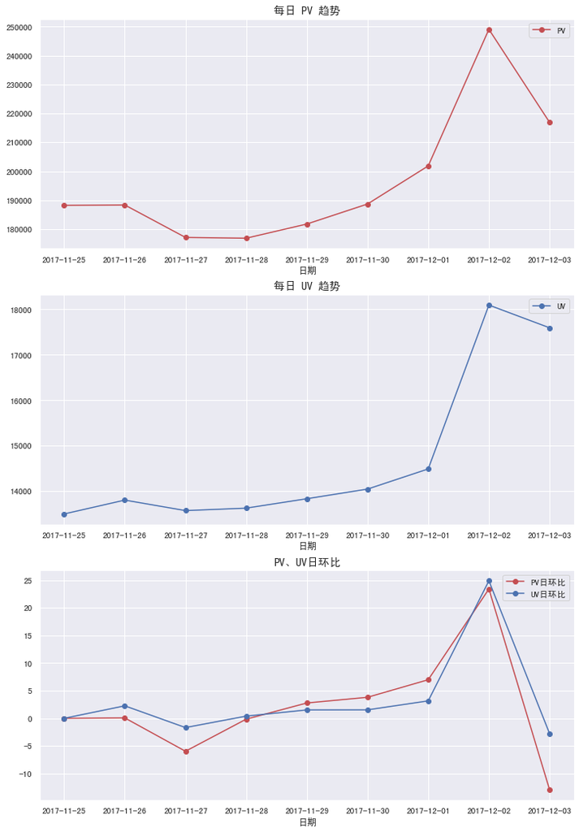

```python
fig,axes=plt.subplots(3,1,figsize=(12,18)) #创建一个一行两列的画布

uv_pv_data['pv'].plot(ax=axes[0],marker='o',color='r',label="PV")
uv_pv_data['uv'].plot(ax=axes[1],marker='o',color='b',label="UV")

uv_pv_data['pv_dayonday'].plot(ax=axes[2],marker='o',color='r',label="PV日环比")
uv_pv_data['uv_dayonday'].plot(ax=axes[2],marker='o',color='b',label="UV日环比")

axes[0].set_title('每日 PV 趋势',fontsize=14)
axes[1].set_title('每日 UV 趋势',fontsize=14)
axes[2].set_title('PV、UV日环比',fontsize=14)
axes[0].set_xlabel('日期')
axes[1].set_xlabel('日期')
axes[2].set_xlabel('日期')
axes[0].legend()
axes[1].legend()
axes[2].legend()
```

- 日pv、日uv 整体呈现上升趋势，在12月2日达到最高峰、3日有所回落，PV日环比、UV日环比在12月2日增长接近25%
- 上述指标都在12月2日~ 3日有了大幅度提升，12月2日~ 3日虽然是周末，但是结合上个周末11月25日~ 26日的流量分析，可以排除周末原因；由于12月2日~3日距离双12较近，推测较大可能的原因是双12系列促销活动预热所带来的流量增加。

## 漏斗分析

用户使用淘宝的常见过程是：浏览（PV），之后可以收藏（fav）、加入购物车（cart），再到购买（buy）。其中，fav、cart不是购买的必须过程。

收藏功能主要是帮助用户收藏自己喜欢但不立即购买的商品，而购物车既有类似收藏商品的功能，但主要还是方便用户批量购买商品，两者都是用于提升用户购物体验。但是商品收藏之后要购买还是面临着加入购物车和直接购买的选择，因此，本文的漏斗分析会将收藏排除在外，由于数据集的行为类型有限，没有下单、支付环节，这里只分析浏览、加购物车、购买的转化。

- 转化节点：**浏览、加购物车、购买**
- 时间窗口：9天
- 转化基线：**每一步作为下一步的基线**
- 转化路径：
  - 转化路径一：浏览-加购物车-购买
  - 转化路径二：浏览-购买

#### 注意

分析的数据集中一共有19543名用户，其中有浏览行为的用户有19462名，说明有81名用户没有浏览行为。由于之前排除了2017年11月25日~2017年12月3日范围外的用户行为记录，所以很可能是，这81名用户的浏览行为是在2017年11月25日之前就发生了。所以这里排除这81名用户的数据。

```python
# 总用户数
total_users = user_behavior['user_id'].nunique()

# UV数
pv_users= user_behavior[user_behavior['behavior_type']=='pv']['user_id'].nunique()

print('总用户数:',total_users,'UV数:',pv_users)
```

```
总用户数: 19543 UV数: 19462
```

```python
# 总用户
total_users_list = user_behavior['user_id'].unique()

# UV
pv_users_list = user_behavior[user_behavior['behavior_type']=='pv']['user_id'].unique()

# 找到两者的差集
np.setdiff1d(total_users_list,pv_users_list)
```

```
array([   1365,    1679,   10694,   11921,   14888,   16641,   16788,
        104460,  104642,  105479,  107243,  108073,  110487,  110938,
        111233,  111904,  112450,  114283,  115685,  117205,  117360,
        117708,  119999,  120134,  122578,  124506,  124587,  126039,
        126062,  128379,  131618,  134710,  134950,  136021,  137661,
        137972,  138088,  138810,  140376,  142109,  142305,  142573,
        142699,  142816,  143670,  144048,  145459,  147016,  147509,
        148260,  148792,  150764,  151163,  152354,  153975,  154034,
        155381,  157324,  157565,  158229,  161910,  162263,  163229,
        163293,  166860,  170144,  170449,  171007,  171362,  171407,
        172198,  172496,  172676, 1001148, 1003646, 1003767, 1004458,
       1005688, 1005897, 1009964, 1017910])
```

```python
# 浏览个别用户行为数据
user_behavior[user_behavior['user_id']==1679]
```

|  | user_id | item_id | category_id | behavior_type | timestamp | date | year_month | hour |
| --- | --- | --- | --- | --- | --- | --- | --- | --- |
| 1854691 | 1679 | 1491518 | 2355072 | cart | 2017-11-25 01:44:03 | 2017-11-25 | 2017-11 | 1 |
| 1854692 | 1679 | 1048127 | 4789432 | cart | 2017-11-26 14:12:42 | 2017-11-26 | 2017-11 | 14 |
| 1854693 | 1679 | 3987147 | 4789432 | cart | 2017-11-26 14:14:47 | 2017-11-26 | 2017-11 | 14 |
| 1854694 | 1679 | 5099698 | 2885642 | buy | 2017-11-26 14:17:43 | 2017-11-26 | 2017-11 | 14 |
| 1854695 | 1679 | 3987147 | 4789432 | buy | 2017-11-28 00:59:54 | 2017-11-28 | 2017-11 | 0 |
| 1854696 | 1679 | 1808917 | 1320293 | cart | 2017-11-28 01:47:20 | 2017-11-28 | 2017-11 | 1 |
| 1854697 | 1679 | 4663016 | 982926 | cart | 2017-11-28 01:49:37 | 2017-11-28 | 2017-11 | 1 |
| 1854698 | 1679 | 624903 | 1080785 | cart | 2017-11-28 08:09:08 | 2017-11-28 | 2017-11 | 8 |
| 1854699 | 1679 | 2490581 | 1817004 | cart | 2017-11-28 08:49:05 | 2017-11-28 | 2017-11 | 8 |
| 1854700 | 1679 | 3333944 | 1817004 | cart | 2017-11-28 09:55:39 | 2017-11-28 | 2017-11 | 9 |
| 1854701 | 1679 | 2998650 | 4357323 | cart | 2017-11-28 10:46:31 | 2017-11-28 | 2017-11 | 10 |
| 1854702 | 1679 | 637045 | 4357323 | cart | 2017-11-28 10:49:14 | 2017-11-28 | 2017-11 | 10 |
| 1854703 | 1679 | 2445510 | 411153 | cart | 2017-11-28 11:00:37 | 2017-11-28 | 2017-11 | 11 |
| 1854704 | 1679 | 39498 | 3673049 | cart | 2017-11-28 11:50:27 | 2017-11-28 | 2017-11 | 11 |
| 1854705 | 1679 | 2868665 | 3673049 | cart | 2017-11-28 12:11:08 | 2017-11-28 | 2017-11 | 12 |
| 1854706 | 1679 | 1523499 | 411153 | cart | 2017-11-28 12:45:27 | 2017-11-28 | 2017-11 | 12 |
| 1854707 | 1679 | 2882647 | 3673049 | cart | 2017-11-29 03:40:31 | 2017-11-29 | 2017-11 | 3 |
| 1854708 | 1679 | 2961294 | 2355072 | cart | 2017-11-29 03:45:10 | 2017-11-29 | 2017-11 | 3 |
| 1854709 | 1679 | 3726128 | 3673049 | cart | 2017-11-29 03:46:03 | 2017-11-29 | 2017-11 | 3 |
| 1854710 | 1679 | 4484120 | 2355072 | cart | 2017-11-29 04:05:45 | 2017-11-29 | 2017-11 | 4 |
| 1854711 | 1679 | 2287412 | 2355072 | cart | 2017-11-29 12:03:08 | 2017-11-29 | 2017-11 | 12 |
| 1854712 | 1679 | 3159038 | 2355072 | cart | 2017-11-29 12:04:30 | 2017-11-29 | 2017-11 | 12 |
| 1854713 | 1679 | 1503702 | 4756105 | cart | 2017-11-29 12:29:02 | 2017-11-29 | 2017-11 | 12 |
| 1854714 | 1679 | 2263826 | 982926 | cart | 2017-11-30 02:56:56 | 2017-11-30 | 2017-11 | 2 |
| 1854715 | 1679 | 3159978 | 4756105 | cart | 2017-11-30 02:59:42 | 2017-11-30 | 2017-11 | 2 |
| 1854716 | 1679 | 390841 | 3673049 | cart | 2017-11-30 03:44:07 | 2017-11-30 | 2017-11 | 3 |
| 1854717 | 1679 | 148411 | 2355072 | cart | 2017-11-30 10:26:45 | 2017-11-30 | 2017-11 | 10 |
| 1854718 | 1679 | 3032345 | 2131531 | cart | 2017-11-30 10:49:16 | 2017-11-30 | 2017-11 | 10 |
| 1854719 | 1679 | 1191753 | 2131531 | cart | 2017-11-30 12:05:32 | 2017-11-30 | 2017-11 | 12 |
| 1854720 | 1679 | 5148912 | 2131531 | cart | 2017-12-01 09:44:25 | 2017-12-01 | 2017-12 | 9 |
| 1854721 | 1679 | 3606439 | 2131531 | cart | 2017-12-01 12:21:34 | 2017-12-01 | 2017-12 | 12 |
| 1854722 | 1679 | 2927801 | 2131531 | cart | 2017-12-01 12:29:23 | 2017-12-01 | 2017-12 | 12 |
| 1854723 | 1679 | 1352908 | 2131531 | cart | 2017-12-01 12:29:49 | 2017-12-01 | 2017-12 | 12 |
| 1854724 | 1679 | 3971945 | 2465336 | cart | 2017-12-01 12:30:57 | 2017-12-01 | 2017-12 | 12 |
| 1854725 | 1679 | 1184759 | 2885642 | cart | 2017-12-02 10:22:14 | 2017-12-02 | 2017-12 | 10 |
| 1854726 | 1679 | 1594562 | 2885642 | cart | 2017-12-02 10:25:20 | 2017-12-02 | 2017-12 | 10 |
| 1854727 | 1679 | 699950 | 2885642 | cart | 2017-12-02 10:30:02 | 2017-12-02 | 2017-12 | 10 |
| 1854728 | 1679 | 4183606 | 4801426 | cart | 2017-12-03 08:12:33 | 2017-12-03 | 2017-12 | 8 |
| 1854729 | 1679 | 2141661 | 2520377 | cart | 2017-12-03 08:22:45 | 2017-12-03 | 2017-12 | 8 |

#### 子集处理

```python
# 构造漏斗分析的子集
funnel_data = user_behavior[["user_id","behavior_type"]]

# 去重处理：对每个用户去除相同行为，因为分析时只需要知道有没有对应的行为，而不需要知道行为的数量
funnel_data = funnel_data.drop_duplicates()
```

```python
# 将用户路径组合起来
funnel_route = funnel_data.groupby('user_id')['behavior_type'].apply('-'.join).reset_index()

# 计算每种路径组合的用户数
funnel_route = funnel_route.groupby('behavior_type')['user_id'].nunique().reset_index()

# 为了助于理解，对字段进行更名处理
funnel_route.rename(columns={"behavior_type":"user_route","user_id":"user_amount"},inplace=True)
funnel_route
```

|  | user_route | user_amount |
| --- | --- | --- |
| 0 | buy | 1 |
| 1 | buy-cart | 8 |
| 2 | buy-cart-fav | 2 |
| 3 | buy-cart-pv | 44 |
| 4 | buy-cart-pv-fav | 8 |
| 5 | buy-fav | 1 |
| 6 | buy-fav-cart | 1 |
| 7 | buy-fav-cart-pv | 2 |
| 8 | buy-fav-pv | 9 |
| 9 | buy-fav-pv-cart | 15 |
| 10 | buy-pv | 137 |
| 11 | buy-pv-cart | 316 |
| 12 | buy-pv-cart-fav | 57 |
| 13 | buy-pv-fav | 72 |
| 14 | buy-pv-fav-cart | 63 |
| 15 | cart | 8 |
| 16 | cart-buy | 20 |
| 17 | cart-buy-fav | 6 |
| 18 | cart-buy-pv | 26 |
| 19 | cart-buy-pv-fav | 8 |
| 20 | cart-fav | 2 |
| 21 | cart-fav-buy | 5 |
| 22 | cart-fav-pv | 11 |
| 23 | cart-fav-pv-buy | 16 |
| 24 | cart-pv | 260 |
| 25 | cart-pv-buy | 579 |
| 26 | cart-pv-buy-fav | 118 |
| 27 | cart-pv-fav | 79 |
| 28 | cart-pv-fav-buy | 116 |
| 29 | fav | 1 |
| 30 | fav-buy | 4 |
| 31 | fav-buy-cart | 8 |
| 32 | fav-buy-pv | 4 |
| 33 | fav-buy-pv-cart | 6 |
| 34 | fav-cart | 3 |
| 35 | fav-cart-buy | 11 |
| 36 | fav-cart-buy-pv | 4 |
| 37 | fav-cart-pv | 11 |
| 38 | fav-cart-pv-buy | 15 |
| 39 | fav-pv | 81 |
| 40 | fav-pv-buy | 119 |
| 41 | fav-pv-buy-cart | 84 |
| 42 | fav-pv-cart | 103 |
| 43 | fav-pv-cart-buy | 158 |
| 44 | pv | 1165 |
| 45 | pv-buy | 1220 |
| 46 | pv-buy-cart | 1636 |
| 47 | pv-buy-cart-fav | 374 |
| 48 | pv-buy-fav | 410 |
| 49 | pv-buy-fav-cart | 329 |
| 50 | pv-cart | 2554 |
| 51 | pv-cart-buy | 3754 |
| 52 | pv-cart-buy-fav | 757 |
| 53 | pv-cart-fav | 553 |
| 54 | pv-cart-fav-buy | 679 |
| 55 | pv-fav | 883 |
| 56 | pv-fav-buy | 798 |
| 57 | pv-fav-buy-cart | 511 |
| 58 | pv-fav-cart | 547 |
| 59 | pv-fav-cart-buy | 771 |

结果有60种组合路径，按照 pv 可以划分为三种情况:

- 不含 pv 【排除，不加入漏斗分析】
- 含 pv
  - 以 pv 开头 【加入漏斗分析】
  - 不以 pv 开头 【拆分后加入漏斗分析】

可以看出，这印证了之前我们的想法，有些用户没有 pv 行为，漏斗分析中我们会排除掉这部分用户。同时也发现了，一些用户路径中 pv 不在开头，所以为了进行完整的漏斗分析，这里会对它进行拆分，分成pv前段和pv后段，仅分析pv后段的路径。

```python
# 排除不含pv的数据

funnel_route = funnel_route[funnel_route['user_route'].str.contains("pv")]
funnel_route
```

|  | user_route | user_amount |
| --- | --- | --- |
| 3 | buy-cart-pv | 44 |
| 4 | buy-cart-pv-fav | 8 |
| 7 | buy-fav-cart-pv | 2 |
| 8 | buy-fav-pv | 9 |
| 9 | buy-fav-pv-cart | 15 |
| 10 | buy-pv | 137 |
| 11 | buy-pv-cart | 316 |
| 12 | buy-pv-cart-fav | 57 |
| 13 | buy-pv-fav | 72 |
| 14 | buy-pv-fav-cart | 63 |
| 18 | cart-buy-pv | 26 |
| 19 | cart-buy-pv-fav | 8 |
| 22 | cart-fav-pv | 11 |
| 23 | cart-fav-pv-buy | 16 |
| 24 | cart-pv | 260 |
| 25 | cart-pv-buy | 579 |
| 26 | cart-pv-buy-fav | 118 |
| 27 | cart-pv-fav | 79 |
| 28 | cart-pv-fav-buy | 116 |
| 32 | fav-buy-pv | 4 |
| 33 | fav-buy-pv-cart | 6 |
| 36 | fav-cart-buy-pv | 4 |
| 37 | fav-cart-pv | 11 |
| 38 | fav-cart-pv-buy | 15 |
| 39 | fav-pv | 81 |
| 40 | fav-pv-buy | 119 |
| 41 | fav-pv-buy-cart | 84 |
| 42 | fav-pv-cart | 103 |
| 43 | fav-pv-cart-buy | 158 |
| 44 | pv | 1165 |
| 45 | pv-buy | 1220 |
| 46 | pv-buy-cart | 1636 |
| 47 | pv-buy-cart-fav | 374 |
| 48 | pv-buy-fav | 410 |
| 49 | pv-buy-fav-cart | 329 |
| 50 | pv-cart | 2554 |
| 51 | pv-cart-buy | 3754 |
| 52 | pv-cart-buy-fav | 757 |
| 53 | pv-cart-fav | 553 |
| 54 | pv-cart-fav-buy | 679 |
| 55 | pv-fav | 883 |
| 56 | pv-fav-buy | 798 |
| 57 | pv-fav-buy-cart | 511 |
| 58 | pv-fav-cart | 547 |
| 59 | pv-fav-cart-buy | 771 |

```python
#拆分不以 pv 开头的路径

# 按正则表达式来分隔，匹配pv前的-号
spliteDF = funnel_route['user_route'].str.split(r'-(?=pv)', 2, True)
spliteDF.columns = ['before-pv', 'after-pv']

spliteDF = pd.concat([funnel_route['user_amount'],spliteDF],axis=1)
spliteDF
```

|  | user_amount | before-pv | after-pv |
| --- | --- | --- | --- |
| 3 | 44 | buy-cart | pv |
| 4 | 8 | buy-cart | pv-fav |
| 7 | 2 | buy-fav-cart | pv |
| 8 | 9 | buy-fav | pv |
| 9 | 15 | buy-fav | pv-cart |
| 10 | 137 | buy | pv |
| 11 | 316 | buy | pv-cart |
| 12 | 57 | buy | pv-cart-fav |
| 13 | 72 | buy | pv-fav |
| 14 | 63 | buy | pv-fav-cart |
| 18 | 26 | cart-buy | pv |
| 19 | 8 | cart-buy | pv-fav |
| 22 | 11 | cart-fav | pv |
| 23 | 16 | cart-fav | pv-buy |
| 24 | 260 | cart | pv |
| 25 | 579 | cart | pv-buy |
| 26 | 118 | cart | pv-buy-fav |
| 27 | 79 | cart | pv-fav |
| 28 | 116 | cart | pv-fav-buy |
| 32 | 4 | fav-buy | pv |
| 33 | 6 | fav-buy | pv-cart |
| 36 | 4 | fav-cart-buy | pv |
| 37 | 11 | fav-cart | pv |
| 38 | 15 | fav-cart | pv-buy |
| 39 | 81 | fav | pv |
| 40 | 119 | fav | pv-buy |
| 41 | 84 | fav | pv-buy-cart |
| 42 | 103 | fav | pv-cart |
| 43 | 158 | fav | pv-cart-buy |
| 44 | 1165 | pv | None |
| 45 | 1220 | pv-buy | None |
| 46 | 1636 | pv-buy-cart | None |
| 47 | 374 | pv-buy-cart-fav | None |
| 48 | 410 | pv-buy-fav | None |
| 49 | 329 | pv-buy-fav-cart | None |
| 50 | 2554 | pv-cart | None |
| 51 | 3754 | pv-cart-buy | None |
| 52 | 757 | pv-cart-buy-fav | None |
| 53 | 553 | pv-cart-fav | None |
| 54 | 679 | pv-cart-fav-buy | None |
| 55 | 883 | pv-fav | None |
| 56 | 798 | pv-fav-buy | None |
| 57 | 511 | pv-fav-buy-cart | None |
| 58 | 547 | pv-fav-cart | None |
| 59 | 771 | pv-fav-cart-buy | None |

```python
def combine(series):
    if series['after-pv'] == None:
        result = series['before-pv']
    else:
        result = series['after-pv']
    return result

spliteDF['route'] = spliteDF.apply(combine,axis=1)
combineDF = spliteDF[['user_amount','route']]
combineDF
```

|  | user_amount | route |
| --- | --- | --- |
| 3 | 44 | pv |
| 4 | 8 | pv-fav |
| 7 | 2 | pv |
| 8 | 9 | pv |
| 9 | 15 | pv-cart |
| 10 | 137 | pv |
| 11 | 316 | pv-cart |
| 12 | 57 | pv-cart-fav |
| 13 | 72 | pv-fav |
| 14 | 63 | pv-fav-cart |
| 18 | 26 | pv |
| 19 | 8 | pv-fav |
| 22 | 11 | pv |
| 23 | 16 | pv-buy |
| 24 | 260 | pv |
| 25 | 579 | pv-buy |
| 26 | 118 | pv-buy-fav |
| 27 | 79 | pv-fav |
| 28 | 116 | pv-fav-buy |
| 32 | 4 | pv |
| 33 | 6 | pv-cart |
| 36 | 4 | pv |
| 37 | 11 | pv |
| 38 | 15 | pv-buy |
| 39 | 81 | pv |
| 40 | 119 | pv-buy |
| 41 | 84 | pv-buy-cart |
| 42 | 103 | pv-cart |
| 43 | 158 | pv-cart-buy |
| 44 | 1165 | pv |
| 45 | 1220 | pv-buy |
| 46 | 1636 | pv-buy-cart |
| 47 | 374 | pv-buy-cart-fav |
| 48 | 410 | pv-buy-fav |
| 49 | 329 | pv-buy-fav-cart |
| 50 | 2554 | pv-cart |
| 51 | 3754 | pv-cart-buy |
| 52 | 757 | pv-cart-buy-fav |
| 53 | 553 | pv-cart-fav |
| 54 | 679 | pv-cart-fav-buy |
| 55 | 883 | pv-fav |
| 56 | 798 | pv-fav-buy |
| 57 | 511 | pv-fav-buy-cart |
| 58 | 547 | pv-fav-cart |
| 59 | 771 | pv-fav-cart-buy |

```python
#由于漏斗分析不分析收藏环节,删掉fav环节

route_data = combineDF.copy()

route_data['route'].replace(r'-fav','',regex=True,inplace=True)
route_data
```

|  | user_amount | route |
| --- | --- | --- |
| 3 | 44 | pv |
| 4 | 8 | pv |
| 7 | 2 | pv |
| 8 | 9 | pv |
| 9 | 15 | pv-cart |
| 10 | 137 | pv |
| 11 | 316 | pv-cart |
| 12 | 57 | pv-cart |
| 13 | 72 | pv |
| 14 | 63 | pv-cart |
| 18 | 26 | pv |
| 19 | 8 | pv |
| 22 | 11 | pv |
| 23 | 16 | pv-buy |
| 24 | 260 | pv |
| 25 | 579 | pv-buy |
| 26 | 118 | pv-buy |
| 27 | 79 | pv |
| 28 | 116 | pv-buy |
| 32 | 4 | pv |
| 33 | 6 | pv-cart |
| 36 | 4 | pv |
| 37 | 11 | pv |
| 38 | 15 | pv-buy |
| 39 | 81 | pv |
| 40 | 119 | pv-buy |
| 41 | 84 | pv-buy-cart |
| 42 | 103 | pv-cart |
| 43 | 158 | pv-cart-buy |
| 44 | 1165 | pv |
| 45 | 1220 | pv-buy |
| 46 | 1636 | pv-buy-cart |
| 47 | 374 | pv-buy-cart |
| 48 | 410 | pv-buy |
| 49 | 329 | pv-buy-cart |
| 50 | 2554 | pv-cart |
| 51 | 3754 | pv-cart-buy |
| 52 | 757 | pv-cart-buy |
| 53 | 553 | pv-cart |
| 54 | 679 | pv-cart-buy |
| 55 | 883 | pv |
| 56 | 798 | pv-buy |
| 57 | 511 | pv-buy-cart |
| 58 | 547 | pv-cart |
| 59 | 771 | pv-cart-buy |

```python
# 将路径划分四类：包含 pv-cart-buy 为一类,包含 pv-cart为一类，包含 pv-buy为一类，最后归为 pv一类

def categorize(series):
    if "pv-cart-buy" in series['route']:
        result = "pv-cart-buy"
    elif "pv-cart" in series['route']:
        result = 'pv-cart'
    elif "pv-buy" in series['route']:
        result = 'pv-buy'
    else:
        result = 'only pv'
    return result


route_data['route_type'] = route_data.apply(categorize,axis=1)
route_data
```

|  | user_amount | route | route_type |
| --- | --- | --- | --- |
| 3 | 44 | pv | only pv |
| 4 | 8 | pv | only pv |
| 7 | 2 | pv | only pv |
| 8 | 9 | pv | only pv |
| 9 | 15 | pv-cart | pv-cart |
| 10 | 137 | pv | only pv |
| 11 | 316 | pv-cart | pv-cart |
| 12 | 57 | pv-cart | pv-cart |
| 13 | 72 | pv | only pv |
| 14 | 63 | pv-cart | pv-cart |
| 18 | 26 | pv | only pv |
| 19 | 8 | pv | only pv |
| 22 | 11 | pv | only pv |
| 23 | 16 | pv-buy | pv-buy |
| 24 | 260 | pv | only pv |
| 25 | 579 | pv-buy | pv-buy |
| 26 | 118 | pv-buy | pv-buy |
| 27 | 79 | pv | only pv |
| 28 | 116 | pv-buy | pv-buy |
| 32 | 4 | pv | only pv |
| 33 | 6 | pv-cart | pv-cart |
| 36 | 4 | pv | only pv |
| 37 | 11 | pv | only pv |
| 38 | 15 | pv-buy | pv-buy |
| 39 | 81 | pv | only pv |
| 40 | 119 | pv-buy | pv-buy |
| 41 | 84 | pv-buy-cart | pv-buy |
| 42 | 103 | pv-cart | pv-cart |
| 43 | 158 | pv-cart-buy | pv-cart-buy |
| 44 | 1165 | pv | only pv |
| 45 | 1220 | pv-buy | pv-buy |
| 46 | 1636 | pv-buy-cart | pv-buy |
| 47 | 374 | pv-buy-cart | pv-buy |
| 48 | 410 | pv-buy | pv-buy |
| 49 | 329 | pv-buy-cart | pv-buy |
| 50 | 2554 | pv-cart | pv-cart |
| 51 | 3754 | pv-cart-buy | pv-cart-buy |
| 52 | 757 | pv-cart-buy | pv-cart-buy |
| 53 | 553 | pv-cart | pv-cart |
| 54 | 679 | pv-cart-buy | pv-cart-buy |
| 55 | 883 | pv | only pv |
| 56 | 798 | pv-buy | pv-buy |
| 57 | 511 | pv-buy-cart | pv-buy |
| 58 | 547 | pv-cart | pv-cart |
| 59 | 771 | pv-cart-buy | pv-cart-buy |

```python
# 按照route_type汇总

route_data = route_data.groupby('route_type')['user_amount'].sum().reset_index()
route_data
```

|  | route_type | user_amount |
| --- | --- | --- |
| 0 | only pv | 2804 |
| 1 | pv-buy | 6325 |
| 2 | pv-cart | 4214 |
| 3 | pv-cart-buy | 6119 |

```python
# 构建两种漏斗表

# 浏览总用户数
pv_users= user_behavior[user_behavior['behavior_type']=='pv']['user_id'].nunique()

# 浏览后加入购物车的用户数
pv_cart_users = route_data[route_data['route_type']=='pv-cart'].user_amount.sum() + route_data[route_data['route_type']=='pv-cart-buy'].user_amount.sum()

# 浏览后加入购物车并购买的用户数
pv_cart_buy_users = route_data[route_data['route_type']=='pv-cart-buy'].user_amount.sum()

# 构建浏览-加入购物车-购买漏斗表
funnel_table_1 = pd.DataFrame({"node":["浏览","加入购物车","购买"],"users":[pv_users,pv_cart_users,pv_cart_buy_users]})

# 浏览后购买的用户数
pv_buy_users = route_data[route_data['route_type']=='pv-buy'].user_amount.sum()

# 构建浏览-加入购物车-购买漏斗表
funnel_table_2 = pd.DataFrame({"node":["浏览","购买"],"users":[pv_users,pv_buy_users]})
```

```python
# 计算第一种漏斗的每一节点转化率

funnel_table_1['conversion_rate'] = round(funnel_table_1["users"]/funnel_table_1["users"].shift(1)*100,2)
# 填充 NAN 值为0
funnel_table_1 = funnel_table_1.fillna(100)
funnel_table_1
```

|  | node | users | conversion_rate |
| --- | --- | --- | --- |
| 0 | 浏览 | 19462 | 100.00 |
| 1 | 加入购物车 | 10333 | 53.09 |
| 2 | 购买 | 6119 | 59.22 |

```python
# 计算第二种漏斗的每一节点转化率

funnel_table_2['conversion_rate'] = round(funnel_table_2["users"]/funnel_table_2["users"].shift(1)*100,2)
# 填充 NAN 值为0
funnel_table_2 = funnel_table_2.fillna(100)
funnel_table_2
```

|  | node | users | conversion_rate |
| --- | --- | --- | --- |
| 0 | 浏览 | 19462 | 100.0 |
| 1 | 购买 | 6325 | 32.5 |

```python
# 制作漏斗图所需的数据格式

def funnel_pairdata(data):
    # func: 制作漏斗图所需的数据格式
    # data: 数据集
    rate_list = []
    for i in range(len(data)):
        x = data.loc[i,'node']
        y = data.loc[i,'conversion_rate']
        rate_list.append((x,y))
    return rate_list

funnel_pairdata(funnel_table_1)
```

```
[('浏览', 100.0), ('加入购物车', 53.09), ('购买', 59.22)]
```

#### 浏览-加购物车-购买三大环节的转化漏斗

```python
# 浏览-加入购物车-购买漏斗图
funnel = Funnel(init_opts=opts.InitOpts(width="800px", height="400px"))

funnel.add(
    series_name='环节',
    data_pair=funnel_pairdata(funnel_table_1),
    sort_= "none",
    tooltip_opts=opts.TooltipOpts(trigger="item", formatter="{a} <br/>{b} : {c}%"),
    label_opts=opts.LabelOpts(is_show=True, position="inside",formatter="{b} {c}%"))

funnel.set_global_opts(
    title_opts=opts.TitleOpts(title="浏览-加购物车-购买三大环节的转化漏斗", subtitle="转化率计算方式：每一步作为下一步的基线",pos_left="center"),
    legend_opts=opts.LegendOpts(pos_left=0,pos_bottom="50%",orient="vertical",item_height=12))

funnel.render_notebook()
```

[output not shown]

转化路径一：浏览-加购物车-购买

- 在9天内，有53.09%的用户在浏览后加入了购物车；
- 其中有59.22%的用户会在加入购物车进行购买行为；
- 由于数据集时间范围的限制，暂时无法知道这各环节的转化率是否正常，需要与历史数据对比才能作出最终的判断。

#### 浏览-购买两大环节的转化漏斗

```python
# 浏览-加入购物车-购买漏斗图
funnel = Funnel(init_opts=opts.InitOpts(width="800px", height="400px"))

funnel.add(
    series_name='环节',
    data_pair=funnel_pairdata(funnel_table_2),
    tooltip_opts=opts.TooltipOpts(trigger="item", formatter="{a} <br/>{b} : {c}%"),
    label_opts=opts.LabelOpts(is_show=True, position="inside",formatter="{b} {c}%"))

funnel.set_global_opts(
    title_opts=opts.TitleOpts(title="浏览-购买两大环节的转化漏斗", subtitle="转化率计算方式：每一步作为下一步的基线",pos_left="center"),
    legend_opts=opts.LegendOpts(pos_left=0,pos_bottom="50%",orient="vertical",item_height=12))

funnel.render_notebook()
```

[output not shown]

转化路径二：浏览-购买

- 在9天内，有32.5%的用户浏览完便会进行购买；
- 由于数据集时间范围的限制，暂时无法知道这各环节的转化率是否正常，需要与历史数据对比才能作出最终的判断。

## 用户行为路径分析

#### 子集处理

```python
# 构建所需子集
route_list = combineDF.copy()
route_list = route_list.groupby('route')['user_amount'].sum().reset_index()
route_list
```

|  | route | user_amount |
| --- | --- | --- |
| 0 | pv | 1754 |
| 1 | pv-buy | 1949 |
| 2 | pv-buy-cart | 1720 |
| 3 | pv-buy-cart-fav | 374 |
| 4 | pv-buy-fav | 528 |
| 5 | pv-buy-fav-cart | 329 |
| 6 | pv-cart | 2994 |
| 7 | pv-cart-buy | 3912 |
| 8 | pv-cart-buy-fav | 757 |
| 9 | pv-cart-fav | 610 |
| 10 | pv-cart-fav-buy | 679 |
| 11 | pv-fav | 1050 |
| 12 | pv-fav-buy | 914 |
| 13 | pv-fav-buy-cart | 511 |
| 14 | pv-fav-cart | 610 |
| 15 | pv-fav-cart-buy | 771 |

可以发现有部分用户购买后，还进行了加购和收藏的行为，说明除了商品页面外，购买后页面有加入购物车和收藏的入口。

为了了解完整的用户行为路径，这里将用户路径进行划分：以浏览为起点，购买为结尾。

```python
#拆分以 buy 结尾的路径

# 按正则表达式来分隔，匹配buy后的-号
splitedata = route_list['route'].str.split(r'(?<=buy)-', 2, True)
splitedata.columns = ['before-buy', 'after-buy']
splitedata = pd.concat([route_list['user_amount'],splitedata['before-buy']],axis=1)

# 汇总
splitedata = splitedata.groupby('before-buy').user_amount.sum().reset_index()

# 为了助于理解，对字段进行更名处理
splitedata.rename(columns={"before-buy":"routes"},inplace=True)


splitedata
```

|  | routes | user_amount |
| --- | --- | --- |
| 0 | pv | 1754 |
| 1 | pv-buy | 4900 |
| 2 | pv-cart | 2994 |
| 3 | pv-cart-buy | 4669 |
| 4 | pv-cart-fav | 610 |
| 5 | pv-cart-fav-buy | 679 |
| 6 | pv-fav | 1050 |
| 7 | pv-fav-buy | 1425 |
| 8 | pv-fav-cart | 610 |
| 9 | pv-fav-cart-buy | 771 |

```python
# 降序
categorized_route = splitedata.sort_values(by ="user_amount",ascending=False)

# 计算占比
categorized_route['percent'] = categorized_route['user_amount']/route_list['user_amount'].sum()

format_dict = {'percent': '{:.2%}'}
(categorized_route.style
              .format(format_dict)
              .bar(color='lightgreen', vmin=0, subset=['percent'], align='zero')
)
```

|  | routes | user_amount | percent |
| --- | --- | --- | --- |
| 1 | pv-buy | 4900 | 25.18% |
| 3 | pv-cart-buy | 4669 | 23.99% |
| 2 | pv-cart | 2994 | 15.38% |
| 0 | pv | 1754 | 9.01% |
| 7 | pv-fav-buy | 1425 | 7.32% |
| 6 | pv-fav | 1050 | 5.40% |
| 9 | pv-fav-cart-buy | 771 | 3.96% |
| 5 | pv-cart-fav-buy | 679 | 3.49% |
| 4 | pv-cart-fav | 610 | 3.13% |
| 8 | pv-fav-cart | 610 | 3.13% |

### 加入购物车、收藏、购买三大功能使用情况

```python
def usage(data):
    fav_usage=0
    cart_usage=0
    buy_usage=0
    for i in range(len(data)):
        if "fav" in data.loc[i,'routes']:
            fav_usage += data.loc[i,'user_amount']
        if "cart" in data.loc[i,'routes']:
            cart_usage +=data.loc[i,'user_amount']
        if "buy" in data.loc[i,'routes']:
            buy_usage +=data.loc[i,'user_amount']
    usage_data= pd.DataFrame({"func":["收藏","加入购物车","购买"],"users":[fav_usage,cart_usage,buy_usage]})
    return usage_data

func_usage = usage(categorized_route)
func_usage
```

```python
# 计算和浏览用户数的占比
func_usage['percent'] = func_usage['users']/pv_users

# 降序
func_usage = func_usage.sort_values(by ="users",ascending=False)

format_dict = {'percent': '{:.2%}'}
(func_usage.style
              .format(format_dict)
              .bar(color='lightgreen', vmin=0, subset=['percent'], align='zero')
)
```

|  | func | users | percent |
| --- | --- | --- | --- |
| 2 | 购买 | 12444 | 63.94% |
| 1 | 加入购物车 | 10333 | 53.09% |
| 0 | 收藏 | 5145 | 26.44% |

- 这9天中，购买的用户占比为63.94%，使用购物车功能用户占比53.09%，使用收藏功能的用户占比26.44%。

### 收藏/加购物车-购买时间间隔分布

用户收藏/加购物车到购买的时间间隔分布，运营人员可以根据时间间隔分布，给用户设置提醒功能。

```python
# 筛选数据集
df_fav = user_behavior[user_behavior["behavior_type"]=="fav"][["user_id","item_id","timestamp"]]
df_cart = user_behavior[user_behavior["behavior_type"]=="cart"][["user_id","item_id","timestamp"]]
df_buy = user_behavior[user_behavior["behavior_type"]=="buy"][["user_id","item_id","timestamp"]]

# 联结两个表
df_cart_buy = pd.merge(df_cart,df_buy,how="inner",on=["user_id","item_id"],suffixes=('_cart', '_buy'))
df_cart_buy["diff_time"] = df_cart_buy["timestamp_buy"]-df_cart_buy["timestamp_cart"]

df_fav_buy = pd.merge(df_fav,df_buy,how="inner",on=["user_id","item_id"],suffixes=('_fav', '_buy'))
df_fav_buy["diff_time"] = df_fav_buy["timestamp_buy"]-df_fav_buy["timestamp_fav"]

# 时间格式转化，单位为小时
df_cart_buy['diff_time'] = df_cart_buy['diff_time'].map(lambda x : x.days * 24 +x.seconds/3600)
df_fav_buy['diff_time'] = df_fav_buy['diff_time'].map(lambda x : x.days * 24 +x.seconds/3600)

# 筛选出时间差大于0的。时间差为负数，表示一个用户购买了一个商品后，再将同一个商品加入购物车的情况
df_cart_buy = df_cart_buy[df_cart_buy["diff_time"]>=0]
df_fav_buy = df_fav_buy[df_fav_buy["diff_time"]>=0]

df_cart_buy
```

|  | user_id | item_id | timestamp_cart | timestamp_buy | diff_time |
| --- | --- | --- | --- | --- | --- |
| 0 | 1000060 | 5129067 | 2017-11-29 06:22:04 | 2017-12-01 03:27:55 | 45.097500 |
| 1 | 1000061 | 3085401 | 2017-11-30 07:12:00 | 2017-12-03 14:42:53 | 79.514722 |
| 2 | 1000061 | 1388090 | 2017-12-01 02:24:30 | 2017-12-03 14:13:00 | 59.808333 |
| 3 | 1000085 | 4382786 | 2017-11-28 11:58:17 | 2017-11-29 09:16:11 | 21.298333 |
| 4 | 1000103 | 808592 | 2017-11-25 11:13:06 | 2017-11-25 11:19:13 | 0.101944 |
| ... | ... | ... | ... | ... | ... |
| 7934 | 174022 | 4103382 | 2017-12-01 14:52:18 | 2017-12-01 15:04:56 | 0.210556 |
| 7935 | 17404 | 4071470 | 2017-11-29 05:34:05 | 2017-11-29 05:43:29 | 0.156667 |
| 7937 | 174044 | 2642191 | 2017-11-29 05:43:48 | 2017-12-02 04:39:57 | 70.935833 |
| 7938 | 174049 | 3431150 | 2017-12-02 09:55:10 | 2017-12-02 16:51:14 | 6.934444 |
| 7939 | 174049 | 3431150 | 2017-12-02 09:55:10 | 2017-12-03 07:40:56 | 21.762778 |

7316 rows × 5 columns

```python
# 分组，一共9天，分为9组
bins = [0,24,48,72,96,120,144,168,192,240]
df_cart_buy["time_bins"] = pd.cut(df_cart_buy["diff_time"],bins=bins,include_lowest=False) # include_lowest:是否包含左端点

bins = [0,24,48,72,96,120,144,168,192,240]
df_fav_buy["time_bins"] = pd.cut(df_fav_buy["diff_time"],bins=bins,include_lowest=False) # include_lowest:是否包含左端点

# 按组统计
cart_df = df_cart_buy.groupby("time_bins").user_id.count()
fav_df = df_fav_buy.groupby("time_bins").user_id.count()

cart_df
```

```
time_bins
(0, 24]       4362
(24, 48]      1401
(48, 72]       682
(72, 96]       381
(96, 120]      211
(120, 144]     134
(144, 168]      87
(168, 192]      44
(192, 240]      14
Name: user_id, dtype: int64
```

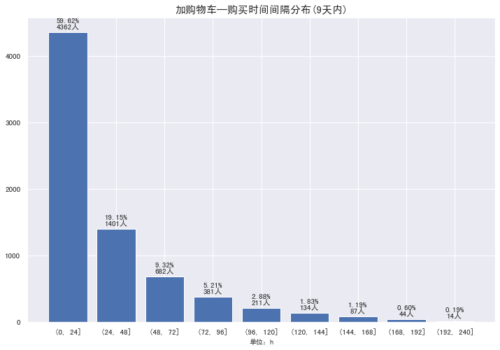

```python
# 绘图 加购物车—购买时间间隔分布
plt.figure(figsize=(12,8))

rects = plt.bar(range(0,len(cart_df.index)),cart_df.values)
plt.xticks(range(0,len(cart_df.index)),cart_df.index)
plt.xlabel("单位：h",fontsize=10)
plt.title("加购物车—购买时间间隔分布(9天内)",fontsize=15)

# 设置数据标签
count=0
Sum=cart_df.sum()
for rect in rects:
    height = rect.get_height()
    rect_x = rect.get_x()
    plt.text(rect.get_x() + rect.get_width()/2,height+50,str(height)+'人', ha='center',fontsize=11)
    plt.text(rect.get_x() + rect.get_width()/2,height+140,str('{:.2f}'.format(cart_df.values[count]/Sum *100)) + "%",ha='center',fontsize=11)
    count=count+1
```

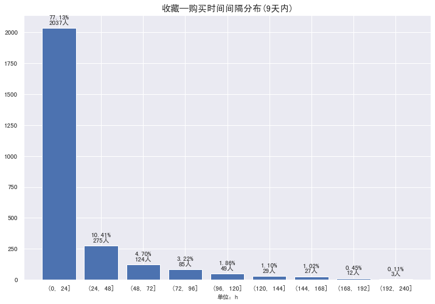

```python
# 绘图 收藏—购买时间间隔分布
plt.figure(figsize=(12,8))

rects = plt.bar(range(0,len(fav_df.index)),fav_df.values)
plt.xticks(range(0,len(fav_df.index)),fav_df.index)
plt.xlabel("单位：h",fontsize=10)
plt.title("收藏—购买时间间隔分布(9天内)",fontsize=15)

# 设置数据标签
count=0
Sum=fav_df.sum()
for rect in rects:
    height = rect.get_height()
    rect_x = rect.get_x()
    plt.text(rect.get_x() + rect.get_width()/2,height+30,str(height)+'人', ha='center',fontsize=11)
    plt.text(rect.get_x() + rect.get_width()/2,height+70,str('{:.2f}'.format(fav_df.values[count]/Sum *100)) + "%",ha='center',fontsize=11)
    count=count+1
```

- 在这9天内，加入购物车且有购买意愿的用户中，接近60%的用户会在24h内完成购买，超过88.09%会在3天内购买；
- 收藏且有购物意愿的用户中，接近77.13%的用户会在24h内完成购买，超过92.24%的用户会在3天内购买。
- 当用户收藏和加购物车3天后还未购买，可以大致推测用户的购买意愿并不强烈，此时可以通过适当的提示\优惠活动来引导用户购买，或者推荐对应的相似商品供用户选择。

回到顶部